# Credit Card Users Churn Prediction

#### **Attrition_Flag Vs Months_on_book**

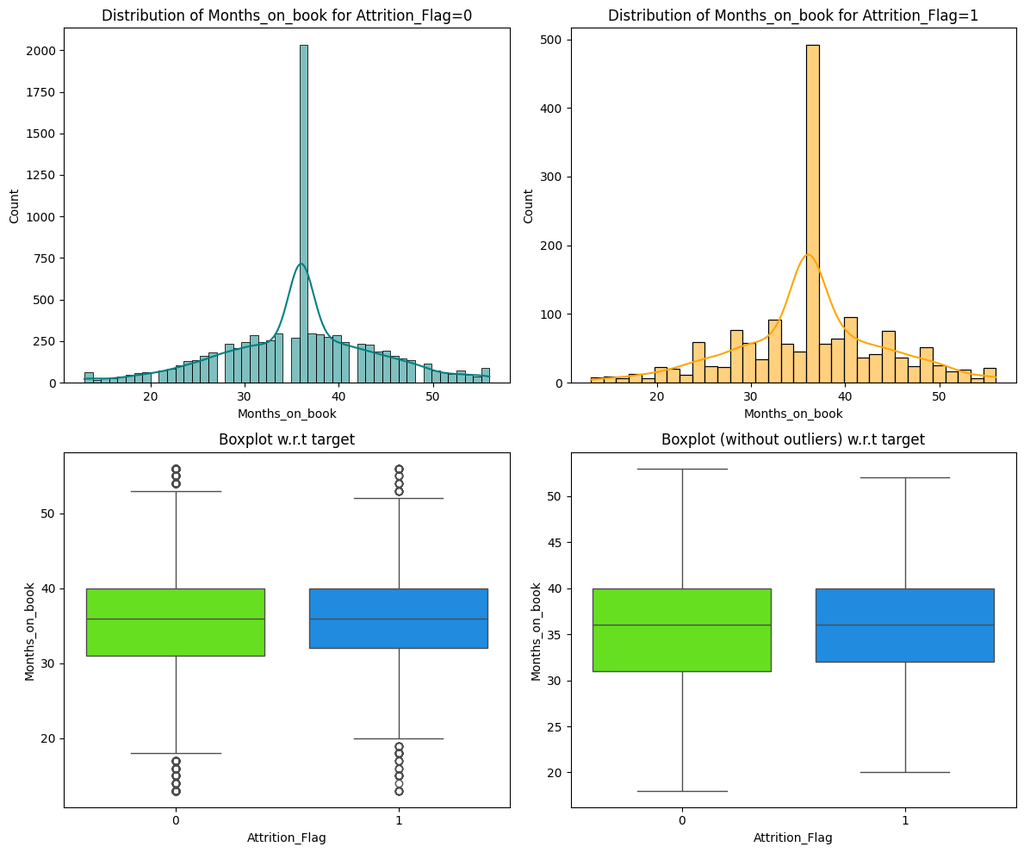

```python
# Lets analyse continuous variables
# Attrition_Flag Vs Months_on_book
distribution_plot_wrt_target(data, "Months_on_book", "Attrition_Flag")
```

#### **Observation**

- Distribution for Existing Customers (Attrition_Flag=0):
  - Strong peak at around 36 months
  - Secondary smaller peaks at different intervals
  - Range primarily between 20-50 months
  - Right-skewed distribution
  - Large spike shows significant customer acquisition around 3 years ago
- Distribution for Attrited Customers (Attrition_Flag=1):
  - Similar peak at 36 months, but proportionally smaller
  - Similar overall pattern to existing customers
  - More evenly distributed across other months
  - Shows same range of 20-50 months
  - Similar spike at 3-year mark
- Boxplot Analysis (with outliers):
  - Median months are very similar for both groups
  - Similar interquartile ranges
  - Both groups show outliers
  - Slightly more spread in existing customer group
- Boxplot Analysis (without outliers):
  - Removes extreme values
  - Shows very similar central tendencies
  - Medians around 35-36 months for both groups
  - Almost identical spreads
- Key Observation:
  - Length of relationship (Months_on_book) is not a strong predictor of attrition
  - Both existing and attrited customers show similar patterns in relationship duration
  - Outliers exist in both groups but don't significantly impact the overall pattern

#### **Attrition_Flag Vs Credit_Limit**

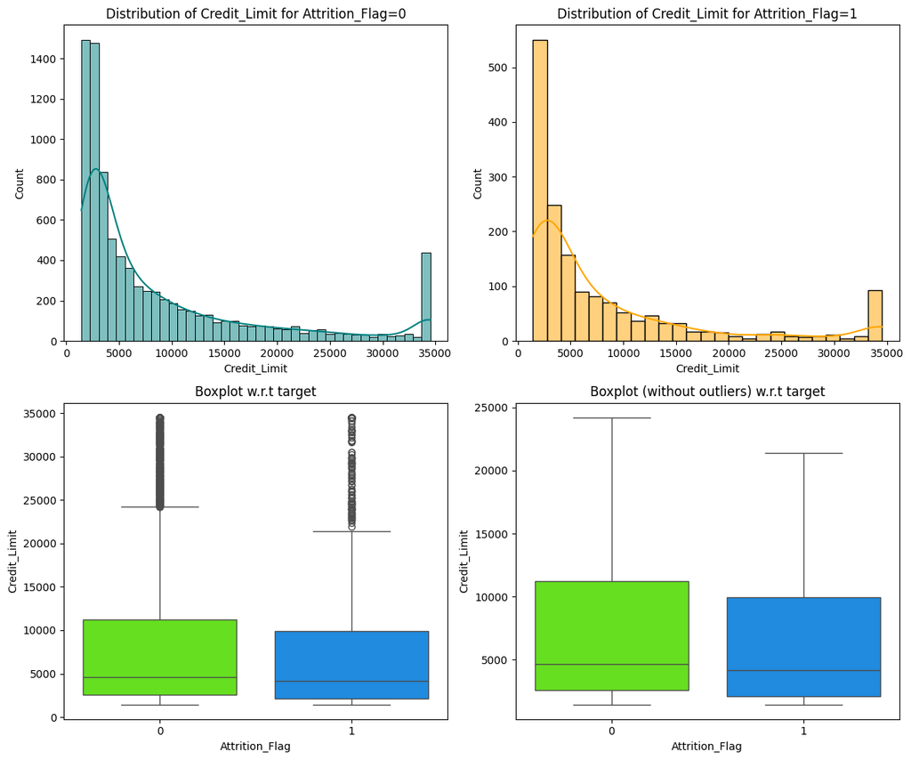

```python
# Lets analyse continuous variables
# Attrition_Flag Vs Credit_Limit
distribution_plot_wrt_target(data, "Credit_Limit", "Attrition_Flag")
```

#### **Observation **

- Distribution for Existing Customers (Attrition_Flag=0):
  - Highly right-skewed distribution
  - Large concentration in lower credit limits (2,000-5,000)
  - Long tail extending to 34,000+
  - Secondary peak at higher credit limits (~34,000)
- Distribution for Attrited Customers (Attrition_Flag=1):
  - Similar right-skewed distribution
  - Also concentrated in lower credit limits
  - Similar pattern but fewer customers overall
  - Proportionally fewer high credit limit customers
  - Similar secondary peak at higher credit limits
- Boxplot Analysis (with outliers):
  - Median credit limit slightly lower for attrited customers
  - Many outliers in both groups
  - Wider spread for existing customers
  - Similar overall range
  - Significant number of high-value outliers
- Boxplot Analysis (without outliers):
  - Clearer view of the central tendency
  - Existing customers have slightly higher median credit limits
  - Similar interquartile ranges
  - Both groups show substantial variation
  - More pronounced difference in medians
- Key Observation:
  - Credit limit distribution is similar between groups but with subtle differences
  - Existing customers tend to have slightly higher credit limits
  - High credit limits don't guarantee customer retention
  - Lower credit limit customers show slightly higher attrition
  - Both groups have significant outliers in higher credit limits

#### **Attrition_Flag Vs Total_Revolving_Bal**

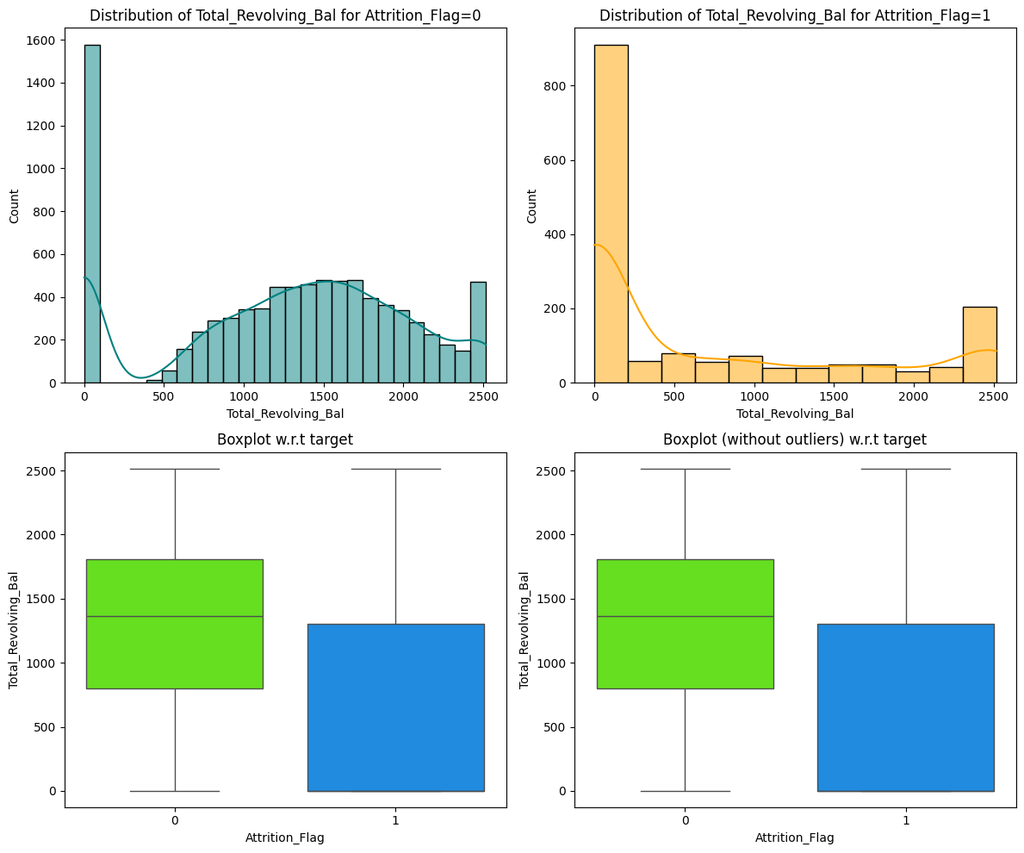

```python
# Lets analyse continuous variables
# Attrition_Flag Vs Total_Revolving_Bal
distribution_plot_wrt_target(data, "Total_Revolving_Bal", "Attrition_Flag")
```

#### **Attrition_Flag Vs Avg_Open_To_Buy**

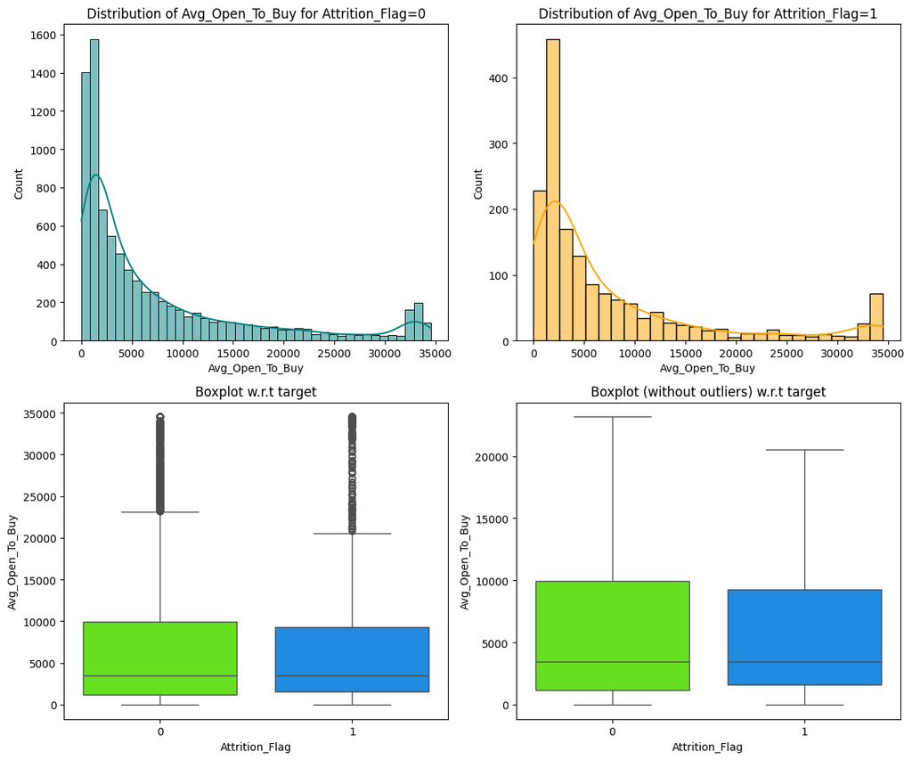

```python
# Lets analyse continuous variables
# Attrition_Flag Vs Avg_Open_To_Buy
distribution_plot_wrt_target(data, "Avg_Open_To_Buy", "Attrition_Flag")
```

#### **Observation**

- Distribution for Existing Customers (Attrition_Flag=0):
  - Right-skewed distribution
  - High peak at lower values (0-5000)
  - Long tail extending to 35,000
  - Secondary small peak at higher values (~34,000)
- Distribution for Attrited Customers (Attrition_Flag=1):
  - Similar right-skewed pattern
  - Also peaks at lower values
  - Proportionally fewer customers with high available credit
  - Similar secondary peak at high values
- Boxplot Analysis (with outliers):
  - Many outliers in both groups
  - Similar median values
  - Slightly higher median for existing customers
  - Large number of high-value outliers
  - Wide range in both groups
- Boxplot Analysis (without outliers):
  - Clearer view of central tendency
  - Very similar distributions between groups
  - Slightly higher values for existing customers
  - Similar interquartile ranges
  - More balanced comparison without extreme values
- Key Observation:
  - Average Open to Buy amounts are similar between groups
  - Slight tendency for existing customers to have higher available credit
  - Pattern closely mirrors Credit_Limit distribution (as expected)

#### **Attrition_Flag Vs Total_Amt_Chng_Q4_Q1**

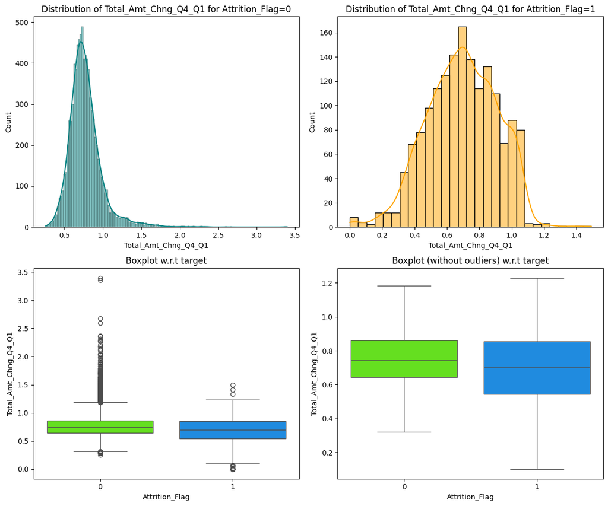

```python
# Lets analyse continuous variables
# Attrition_Flag Vs Total_Amt_Chng_Q4_Q1
distribution_plot_wrt_target(data, "Total_Amt_Chng_Q4_Q1", "Attrition_Flag")
```